# DATA607-FinalPresent

2024-12-18

## Introduction

New York City, known for its bustling streets and iconic yellow cabs, has one of the largest and most dynamic taxi industries in the world. Every day, thousands of yellow cabs navigate the city’s grid, transporting millions of passengers through its diverse boroughs. These cabs are not just a form of transportation—they represent the driving force of a city that never sleeps. As someone who has grown up with cab drivers in my family, I’ve always been intrigued as to what can makes them successful.

## Purpose

This analysis is rooted in the idea that the key to success for a New York City cab driver lies in understanding the data behind their trips and how factors like time of day, route choice, and passenger type influence earnings and overall success. Through a simple analysis of real trip data from NYC cabs, collected in September 2024, I aim to explore what makes a cab driver successful. By studying these patterns, I hope to uncover insights that could help current and aspiring drivers improve their strategies, enhance their efficiency, and ultimately thrive in one of the most competitive and rewarding professions in the city.

## Data Science Workflow

This analysis will follow Hadley Wickham’s Workflow

## The Libraries

```r
library(tidyverse)
library(arrow)
library(rvest)
library(pdftools)
library(tidyr)
```

## Import the Data

From three different sources

```r
data_green_tripdata <- read_parquet("green_tripdata_2024-09.parquet")
data_yellow_tripdata <- read_parquet("yellow_tripdata_2024-09.parquet")

taxi_zone_lookup <- read_csv("taxi_zone_lookup.csv")

pdf_file_yellow <- "data_dictionary_trip_records_yellow.pdf"
pdf_file_green <- "data_dictionary_trip_records_green.pdf"
```

## Data Tidy - Reading PDF’s

```r
pdf_text <- pdftools::pdf_text(pdf_file_yellow)
all_text_yellow <- paste(pdf_text, collapse = "\n")
pdf_text <- pdftools::pdf_text(pdf_file_green)
all_text_green <- paste(pdf_text, collapse = "\n")

print(all_text_yellow)
```

```
## [1] "Data Dictionary – Yellow Taxi Trip Records       May 11, 2022                      Page 1 of 2\n\nThis data dictionary describes yellow taxi trip data. For a dictionary describing green taxi data, or a map\nof the TLC Taxi Zones, please visit http://www.nyc.gov/html/tlc/html/about/trip_recor…
```

## Data Tidy - Using regex to extract the field names and descriptions

```r
lines <- unlist(strsplit(all_text_yellow, "\n"))
lines <- lines[nchar(lines) > 0]  # Remove empty lines
lines <- trimws(lines)  # Trim leading/trailing whitespace
fields <- list()
current_description <- ""
for (line in lines) {
  match <- regexec("^([A-Za-z_]+(?:[A-Za-z0-9_]*))\\s{2,}(.*)$", line)
  matched <- regmatches(line, match)
  if (length(matched[[1]]) > 1) {
    if (nchar(current_description) > 0) {
      fields[[length(fields) + 1]] <- c(field_name, current_description)
    }
    field_name <- matched[[1]][2]
    description <- matched[[1]][3]
    current_description <- description
  } else {
    if (grepl("^\\d=", line)) {
      current_description <- paste(current_description, line)
    }
  }
}
if (nchar(current_description) > 0) {
  fields[[length(fields) + 1]] <- c(field_name, current_description)
}
fields_yellow <- do.call(rbind, fields)
colnames(fields_yellow) <- c("Field_Name", "Description")
```

## Data Tidy - Using regex to extract the field names and descriptions

```r
print(fields_yellow)
```

```
##       Field_Name
##  [1,] "VendorID"
##  [2,] "tpep_pickup_datetime"
##  [3,] "tpep_dropoff_datetime"
##  [4,] "Passenger_count"
##  [5,] "Trip_distance"
##  [6,] "PULocationID"
##  [7,] "DOLocationID"
##  [8,] "RateCodeID"
##  [9,] "Store_and_fwd_flag"
## [10,] "Payment_type"
## [11,] "Fare_amount"
## [12,] "Extra"
## [13,] "MTA_tax"
## [14,] "Improvement_surcharge"
```

[output cut: 25 more lines]

The Same for Green

```r
lines <- unlist(strsplit(all_text_green, "\n"))

lines <- lines[nchar(lines) > 0]  # Remove empty lines
lines <- trimws(lines)  # Trim leading/trailing whitespace

fields <- list()

current_description <- ""

for (line in lines) {
  match <- regexec("^([A-Za-z_]+(?:[A-Za-z0-9_]*))\\s{2,}(.*)$", line)
  matched <- regmatches(line, match)

  if (length(matched[[1]]) > 1) {
    if (nchar(current_description) > 0) {
      fields[[length(fields) + 1]] <- c(field_name, current_description)
    }

    field_name <- matched[[1]][2]
    description <- matched[[1]][3]

    current_description <- description
  } else {
    if (grepl("^\\d=", line)) {
      current_description <- paste(current_description, line)
    }
  }
}

if (nchar(current_description) > 0) {
  fields[[length(fields) + 1]] <- c(field_name, current_description)
}

fields_green <- do.call(rbind, fields)
colnames(fields_green) <- c("Field_Name", "Description")
```

## Data Tidy - Convert the text data into dataframes

```r
fields_df_yellow <- as.data.frame(fields_yellow)
fields_df_green <- as.data.frame(fields_green)
glimpse(fields_df_yellow)
```

```
## Rows: 19
## Columns: 2
## $ Field_Name  <chr> "VendorID", "tpep_pickup_datetime", "tpep_dropoff_datetime…
## $ Description <chr> "A code indicating the TPEP provider that provided the rec…
```

## Data Tidy - Remove Columns not Needed

```r
library(dplyr)
indices_yellow <- which(fields_df_yellow$Field_Name %in% c("VendorID", "RateCodeID", "Payment_type"))
indices_green <- which(fields_df_green$Field_Name %in% c("VendorID", "RateCodeID", "Payment_type", "Trip_type"))

fields_df_yellow <- fields_df_yellow[indices_yellow, ]
fields_df_green <- fields_df_green[indices_green, ]

head(fields_df_yellow)
```

```
##      Field_Name
## 1      VendorID
## 8    RateCodeID
## 10 Payment_type
##                                                                                                                                     Description
## 1                          A code indicating the TPEP provider that provided the record. 1= Creative Mobile Technologies, LLC; 2= VeriFone Inc.
## 8  The final rate code in effect at the end of the trip. 1= Standard rate 2=JFK 3=Newark 4=Nassau or Westchester 5=Negotiated fare 6=Group ride
## 10      A numeric code signifying how the passenger paid for the trip. 1= Credit card 2= Cash 3= No charge 4= Dispute 5= Unknown 6= Voided trip
```

```r
head(fields_df_green)
```

```
##      Field_Name
## 1      VendorID
## 8    RateCodeID
## 10 Payment_type
## 18    Trip_type
##                                                                                                                                     Description
## 1                          A code indicating the LPEP provider that provided the record. 1= Creative Mobile Technologies, LLC; 2= VeriFone Inc.
## 8  The final rate code in effect at the end of the trip. 1= Standard rate 2=JFK 3=Newark 4=Nassau or Westchester 5=Negotiated fare 6=Group ride
## 10      A numeric code signifying how the passenger paid for the trip. 1= Credit card 2= Cash 3= No charge 4= Dispute 5= Unknown 6= Voided trip
## 18                                                A code indicating whether the trip was a street-hail or a dispatch 1= Street-hail 2= Dispatch
```

## Data Tidy - Even More Regex (Also dropped one since they were the same)

```r
library(dplyr)
library(stringr)

fields_df <- fields_df_yellow %>%
  mutate(across(c(-Field_Name), ~ str_extract(.x, "(?<=[^\\d])\\d.*")))

fields_df$Field_Name[2] <- "RatecodeID"
fields_df$Field_Name[3] <- "payment_type"
```

## Data Tidy - Even More Regex (Also dropped one since they were the same)

```r
print(fields_df)
```

```
##      Field_Name
## 1      VendorID
## 8    RatecodeID
## 10 payment_type
##                                                                               Description
## 1                                  1= Creative Mobile Technologies, LLC; 2= VeriFone Inc.
## 8  1= Standard rate 2=JFK 3=Newark 4=Nassau or Westchester 5=Negotiated fare 6=Group ride
## 10               1= Credit card 2= Cash 3= No charge 4= Dispute 5= Unknown 6= Voided trip
```

## Data Tidy - Use regex to convert description in a dictionary.

```r
library(tidyverse)
fields_df_tidy <- fields_df %>%
  mutate(Description = str_split(Description, " (?=\\d+=)")) %>%
  unnest(cols = c(Description)) %>%
  mutate(
    Code_Number = str_extract(Description, "^[0-9]+"),
    Description = str_remove(Description, "^[0-9]+=\\s*")
  ) %>%
  mutate(
    Code_Number = str_trim(Code_Number),
    Description = str_trim(Description)
  )
```

## Data Tidy - Use regex to convert description in a dictionary.

```r
print(fields_df_tidy)
```

```
## # A tibble: 14 × 3
##    Field_Name   Description                        Code_Number
##    <chr>        <chr>                              <chr>
##  1 VendorID     Creative Mobile Technologies, LLC; 1
##  2 VendorID     VeriFone Inc.                      2
##  3 RatecodeID   Standard rate                      1
##  4 RatecodeID   JFK                                2
##  5 RatecodeID   Newark                             3
##  6 RatecodeID   Nassau or Westchester              4
##  7 RatecodeID   Negotiated fare                    5
##  8 RatecodeID   Group ride                         6
##  9 payment_type Credit card                        1
## 10 payment_type Cash                               2
## 11 payment_type No charge                          3
## 12 payment_type Dispute                            4
## 13 payment_type Unknown                            5
## 14 payment_type Voided trip                        6
```

## Data Tidy - Converting Code Number to Numeric

```r
fields_df_tidy$Code_Number <- gsub("[^0-9]", "", fields_df_tidy$Code_Number)
fields_df_tidy$Code_Number <- as.numeric(fields_df_tidy$Code_Number)
glimpse(fields_df_tidy)
```

```
## Rows: 14
## Columns: 3
## $ Field_Name  <chr> "VendorID", "VendorID", "RatecodeID", "RatecodeID", "Ratec…
## $ Description <chr> "Creative Mobile Technologies, LLC;", "VeriFone Inc.", "St…
## $ Code_Number <dbl> 1, 2, 1, 2, 3, 4, 5, 6, 1, 2, 3, 4, 5, 6
```

## Data Tidy - Four Clean Datasets

```r
#data_green_tripdata
#data_yellow_tripdata
#taxi_zone_lookup
#fields_df_tidy
```

## Data Transform - Combining Green and Yellow Data

```r
data_green_tripdata <- data_green_tripdata %>%
  mutate(cab_type = "green")
data_yellow_tripdata <- data_yellow_tripdata %>%
  mutate(cab_type = "yellow")

data_tripdata <- bind_rows(data_green_tripdata, data_yellow_tripdata)
```

## Data Transform - Joining trip data with location Zones

```r
data_tripdata <- data_tripdata %>%
  left_join(taxi_zone_lookup %>%
              select(LocationID, Zone) %>%
              rename(PUZone = Zone),
            by = c("PULocationID" = "LocationID"))

data_tripdata <- data_tripdata %>%
  left_join(taxi_zone_lookup %>%
              select(LocationID, Zone) %>%
              rename(DOZone = Zone),
            by = c("DOLocationID" = "LocationID"))
```

## Data Transform - Joining trip data with ID values from dictionary

```r
data_tripdata <- data_tripdata %>%
  left_join(fields_df_tidy %>%
              filter(Field_Name == "VendorID") %>%
              select(Code_Number, Description) %>%
              rename(VendorDescription = Description),
            by = c("VendorID" = "Code_Number"))

data_tripdata <- data_tripdata %>%
  left_join(fields_df_tidy %>%
              filter(Field_Name == "RatecodeID") %>%
              select(Code_Number, Description) %>%
              rename(RatecodeDescription = Description),
            by = c("RatecodeID" = "Code_Number"))

data_tripdata <- data_tripdata %>%
  left_join(fields_df_tidy %>%
              filter(Field_Name == "payment_type") %>%
              select(Code_Number, Description) %>%
              rename(PaymentTypeDescription = Description),
            by = c("payment_type" = "Code_Number"))
```

## Data Transform - All Four Datasets Joined

```
## Rows: 3,687,470
## Columns: 29
## $ VendorID               <dbl> 2, 2, 2, 2, 2, 2, 2, 2, 2, 2, 2, 2, 2, 2, 2, 2,…
## $ lpep_pickup_datetime   <dttm> 2024-08-31 20:06:40, 2024-08-31 20:51:31, 2024…
## $ lpep_dropoff_datetime  <dttm> 2024-08-31 20:31:15, 2024-08-31 21:14:11, 2024…
## $ store_and_fwd_flag     <chr> "N", "N", "N", "N", "N", "N", "N", "N", "N", "N…
## $ RatecodeID             <dbl> 1, 1, 1, 1, 5, 1, 1, 1, 1, 1, 1, 5, 1, 1, 1, 1,…
## $ PULocationID           <dbl> 92, 80, 42, 41, 42, 223, 93, 66, 66, 130, 74, 9…
## $ DOLocationID           <dbl> 37, 80, 116, 42, 42, 83, 10, 148, 262, 191, 42,…
## $ passenger_count        <int> 1, 1, 1, 1, 1, 1, 1, 1, 1, 1, 1, 2, 1, 1, 1, 2,…
## $ trip_distance          <dbl> 10.66, 3.89, 0.80, 1.84, 0.00, 2.19, 7.27, 3.15…
## $ fare_amount            <dbl> 43.6, 22.6, 6.5, 11.4, 29.0, 11.4, 30.3, 19.8, …
## $ extra                  <dbl> 1, 1, 1, 1, 0, 1, 1, 1, 1, 1, 1, 0, 1, 1, 1, 1,…
## $ mta_tax                <dbl> 0.5, 0.5, 0.5, 0.5, 0.0, 0.5, 0.5, 0.5, 0.5, 0.…
## $ tip_amount             <dbl> 0.00, 5.02, 0.00, 0.00, 0.00, 0.00, 6.56, 5.01,…
```

[output cut: 16 more lines]

## Data Transform - Calculate total time between pickup and dropoff

```r
data_tripdata$total_time <- with(data_tripdata, {
  time1 <- ifelse(!is.na(lpep_pickup_datetime) & !is.na(lpep_dropoff_datetime),
                  as.numeric(difftime(lpep_dropoff_datetime, lpep_pickup_datetime, units = "mins")), 0)
  time2 <- ifelse(!is.na(tpep_pickup_datetime) & !is.na(tpep_dropoff_datetime),
                  as.numeric(difftime(tpep_dropoff_datetime, tpep_pickup_datetime, units = "mins")), 0)

  time1 + time2
})

glimpse(data_tripdata$total_time)
```

```
##  num [1:3687470] 24.58 22.67 4.27 8.68 1.35 ...
```

## Data Transform - Dropping features not need for this analysis.

```r
data_tripdata <- data_tripdata %>%
  select(-lpep_pickup_datetime, -lpep_dropoff_datetime, -tpep_pickup_datetime, -tpep_dropoff_datetime, -VendorID, -RatecodeID, -PULocationID, -DOLocationID, -payment_type, -trip_type, -store_and_fwd_flag)

glimpse(data_tripdata)
```

```
## Rows: 3,687,470
## Columns: 19
## $ passenger_count        <int> 1, 1, 1, 1, 1, 1, 1, 1, 1, 1, 1, 2, 1, 1, 1, 2,…
## $ trip_distance          <dbl> 10.66, 3.89, 0.80, 1.84, 0.00, 2.19, 7.27, 3.15…
## $ fare_amount            <dbl> 43.6, 22.6, 6.5, 11.4, 29.0, 11.4, 30.3, 19.8, …
## $ extra                  <dbl> 1, 1, 1, 1, 0, 1, 1, 1, 1, 1, 1, 0, 1, 1, 1, 1,…
## $ mta_tax                <dbl> 0.5, 0.5, 0.5, 0.5, 0.0, 0.5, 0.5, 0.5, 0.5, 0.…
## $ tip_amount             <dbl> 0.00, 5.02, 0.00, 0.00, 0.00, 0.00, 6.56, 5.01,…
## $ tolls_amount           <dbl> 0.00, 0.00, 0.00, 0.00, 0.00, 0.00, 0.00, 0.00,…
## $ ehail_fee              <dbl> NA, NA, NA, NA, NA, NA, NA, NA, NA, NA, NA, NA,…
## $ improvement_surcharge  <dbl> 1, 1, 1, 1, 1, 1, 1, 1, 1, 1, 1, 1, 1, 1, 1, 1,…
## $ total_amount           <dbl> 46.10, 30.12, 9.00, 13.90, 30.00, 13.90, 39.36,…
## $ congestion_surcharge   <dbl> 0.00, 0.00, 0.00, 0.00, 0.00, 0.00, 0.00, 2.75,…
## $ cab_type               <chr> "green", "green", "green", "green", "green", "g…
## $ Airport_fee            <dbl> NA, NA, NA, NA, NA, NA, NA, NA, NA, NA, NA, NA,…
## $ PUZone                 <chr> "Flushing", "East Williamsburg", "Central Harle…
## $ DOZone                 <chr> "Bushwick South", "East Williamsburg", "Hamilto…
## $ VendorDescription      <chr> "VeriFone Inc.", "VeriFone Inc.", "VeriFone Inc…
## $ RatecodeDescription    <chr> "Standard rate", "Standard rate", "Standard rat…
## $ PaymentTypeDescription <chr> "Cash", "Credit card", "Credit card", "Cash", "…
## $ total_time             <dbl> 24.583333, 22.666667, 4.266667, 8.683333, 1.350…
```

## Data Transform - Finding and Replacing features with na values

```
##        passenger_count          trip_distance            fare_amount
##                 485435                      0                      0
##                  extra                mta_tax             tip_amount
##                      0                      0                      0
##           tolls_amount              ehail_fee  improvement_surcharge
##                      0                3687470                      0
##           total_amount   congestion_surcharge               cab_type
##                      0                 485435                      0
##            Airport_fee                 PUZone                 DOZone
##                 538171                      0                      0
##      VendorDescription    RatecodeDescription PaymentTypeDescription
##                    109                 522998                 485435
##             total_time
##                      0
```

## Data Transform - Finding and Replacing features with na values

```
##        passenger_count          trip_distance            fare_amount
##                 485435                      0                      0
##                  extra                mta_tax             tip_amount
##                      0                      0                      0
##           tolls_amount              ehail_fee  improvement_surcharge
##                      0                      0                      0
##           total_amount   congestion_surcharge               cab_type
##                      0                      0                      0
##            Airport_fee                 PUZone                 DOZone
##                      0                      0                      0
##      VendorDescription    RatecodeDescription PaymentTypeDescription
##                    109                 522998                 485435
##             total_time
##                      0
```

## EDA - Using ggplot2 for visualizations

```r
library(ggplot2)
```

## EDA - Top 10 Most Frequent Pick-up Zones

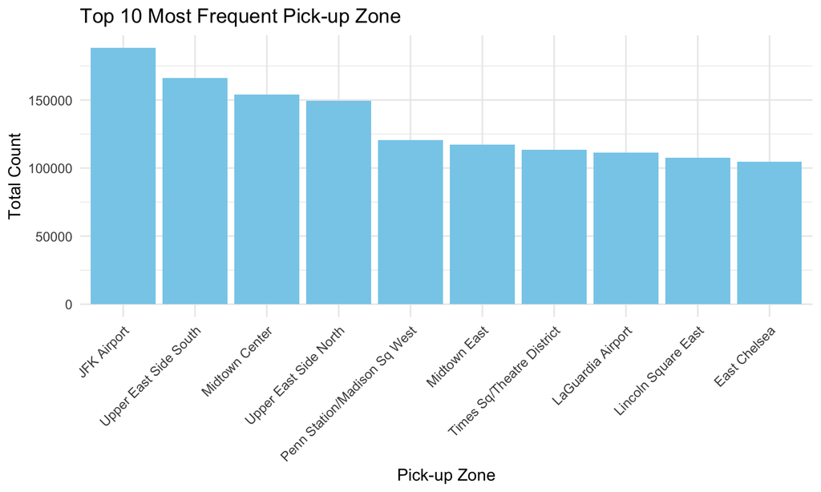

## EDA - Top 10 Most Frequent Drop-off Zones

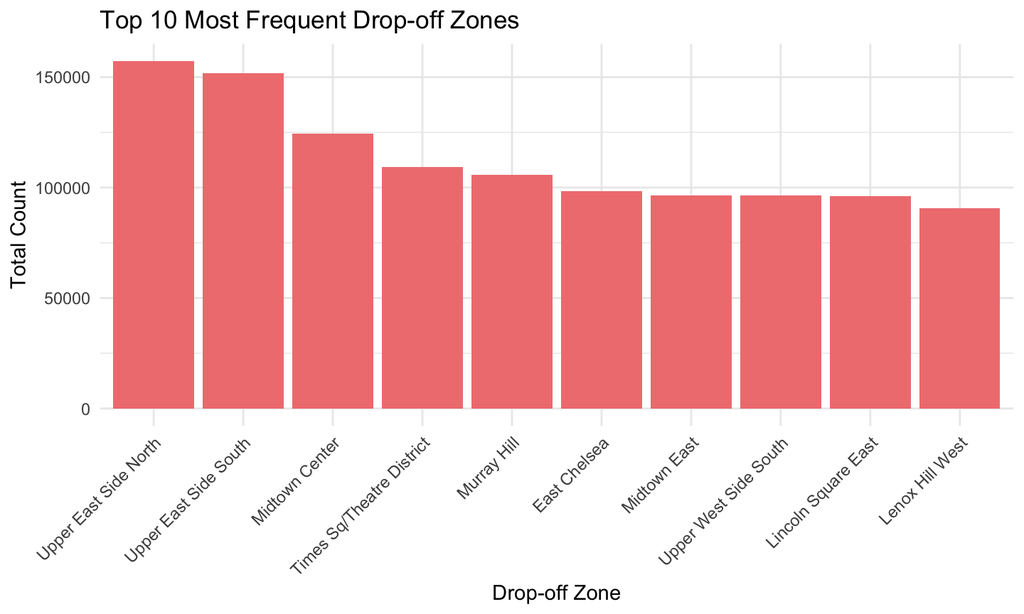

## EDA - Frequency by payment type

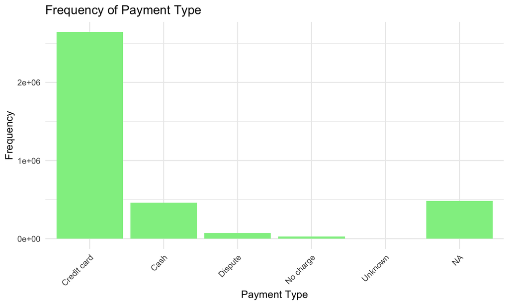

## EDA - Density Plot of Total Amount (Somethings Wrong)

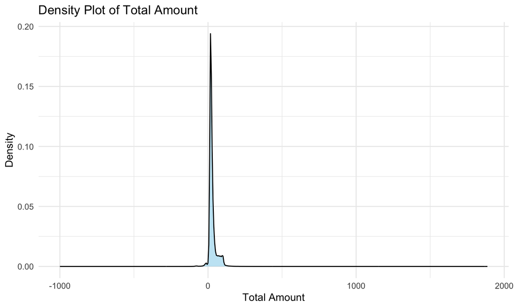

## EDA - Fixing Outlier’s

```r
summary(data_tripdata$total_amount)
```

```
##     Min.  1st Qu.   Median     Mean  3rd Qu.     Max.
## -1000.00    15.96    21.48    28.51    31.50  1886.02
```

```r
data_tripdata <- data_tripdata %>%
  filter(total_amount >= 0)

count_above_500 <- data_tripdata %>%
  filter(total_amount > 500) %>%
  nrow()
count_above_500
```

```
## [1] 83
```

```
##    Min. 1st Qu.  Median    Mean 3rd Qu.    Max.
##    0.00   16.30   21.80   29.39   31.85  500.00
```

## EDA - Fixed Density Plot

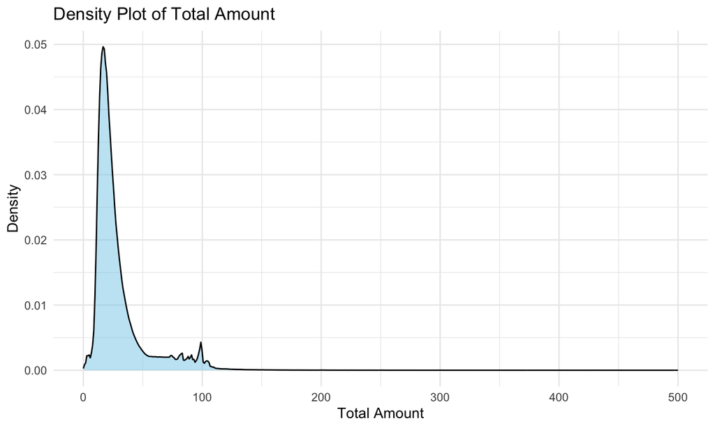

## EDA - Top 15 Pickup Zones total average amount

```
## # A tibble: 6 × 2
##   PUZone                            avg_total_amount
##   <chr>                                        <dbl>
## 1 Rossville/Woodrow                            131.
## 2 Outside of NYC                               104.
## 3 Newark Airport                                94.5
## 4 JFK Airport                                   82.9
## 5 Eltingville/Annadale/Prince's Bay             74.8
## 6 Baisley Park                                  70.6
```

## EDA - Top 15 Pickup Zones total average amount

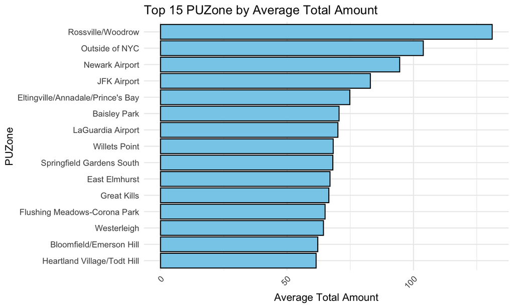

## EDA - Top 15 drop off zones by avg total amount

```
## # A tibble: 6 × 2
##   DOZone                            avg_total_amount
##   <chr>                                        <dbl>
## 1 Freshkills Park                               205.
## 2 Arden Heights                                 161.
## 3 Rossville/Woodrow                             154.
## 4 Eltingville/Annadale/Prince's Bay             145.
## 5 Charleston/Tottenville                        145.
## 6 Great Kills                                   140.
```

## EDA - Top 15 drop off zones by avg total amount

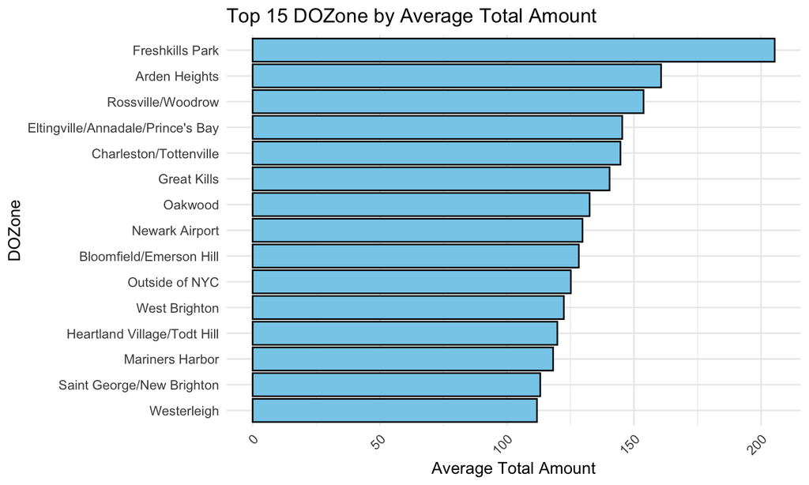

## EDA - Average Total Amount by Cab Type

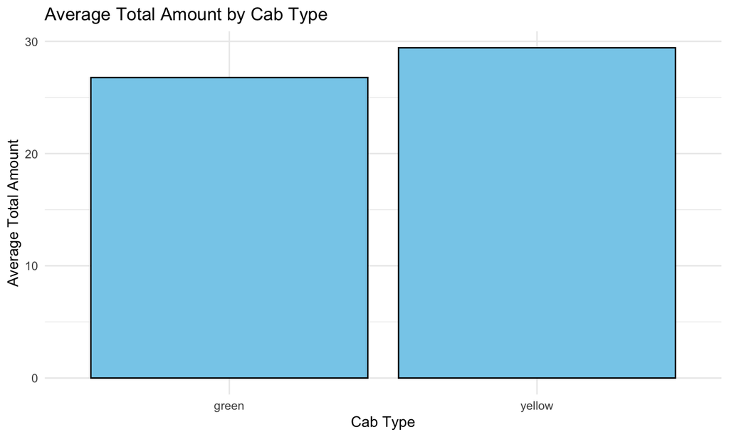

## EDA - Top 10 PUZone by Total Amount (Trips > 100)

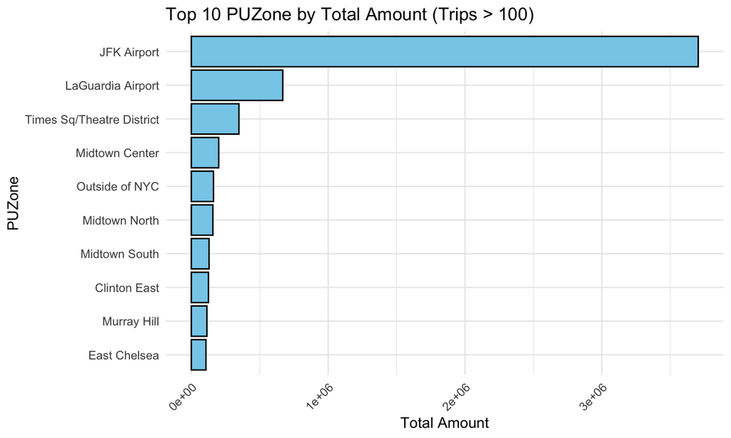

## EDA - Is there a correlation between longer trips and amount earned?

```r
filtered_data <- data_tripdata %>%
  filter(total_time >= 0 & total_time <= 360)

correlation_filtered <- cor(filtered_data$total_time, filtered_data$total_amount, use = "complete.obs")
correlation_filtered
```

```
## [1] 0.7604364
```

## EDA - Is there a correlation between longer trips and amount earned?

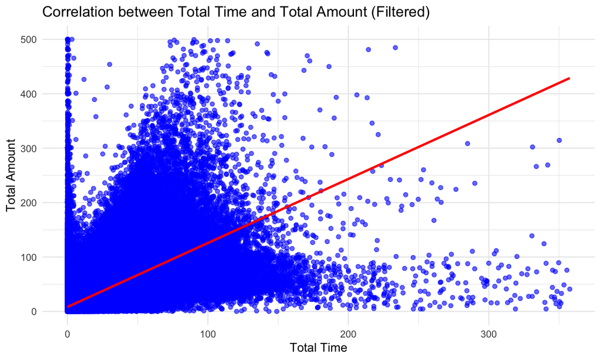

## Conclusions - Basics

- On average you make 29.39 per trip as a cab driver in NYC.
- Yellow makes more on average then green cab.
- Longer drives don’t always earn a significant amount more.
- $15 - $30 is a good expected range however there was 63,000+ $100 trips in September.
- An overwhelming majority of $100+ are from JFK then Laguardia.

## Conclusions - Top 5 pickups zones by average earned is

- Rossville/Woodrow $131.10667
- Outside of NYC $103.87056
- Newark Airport $94.54231
- JFK Airport $82.94165
- Eltingville/Annadale/Prince’s Bay $74.82500

## Conclusions - Top 5 dropoff zones by average earned is

- Freshkills Park $205.3375
- Arden Heights $160.6545
- Rossville/Woodrow 153.7494
- Eltingville/Annadale/Prince’s Bay $145.3672
- Charleston/Tottenville $144.6669
- Great Kills $140.3974

## Conclusions - Recommend

So if you want to be a succesful cab driver then your better off driving a yellow cab and taking as much trips from JFK as you can. However the most profitable routes are usually from and to Staten Island.

## Challenges

- Getting the Taxi Dictionary to work
- Wasn’t able to webscrape into a dataframe
- Download PDF
- Use multiple stages of regex and extract
- Finally tidy data dictionary

## Things learned not learned in class

- Working with PDF’s
- Building Slides from R using ioslides

## Questions/Answers

-Have any questions?